# Notebook Structure

1. Import necessary dependencies
2. Create dataset
3. Jointplot visualization for the numerical features
4. How to interpret Jointplot

# 1. Import necessary dependencies

```python
# libraries & dataset
import matplotlib.pyplot as plt
import numpy as np
import seaborn as sns
import pandas as pd


sns.set_theme(style="darkgrid")
```

# 2. Create the dataset

```python
# 1. Create a dataset with around 10 numerical variables
# Using a dictionary to create the data, then converting to a DataFrame
data = {
    'StockPrice': np.random.normal(100, 15, 100),  # Example stock price
    'EPS': np.random.normal(5, 2, 100),             # Earnings per share
    'PE_Ratio': np.random.normal(20, 5, 100),        # Price-to-earnings ratio
    'DebtToEquity': np.random.uniform(0, 2, 100),   # Debt-to-equity ratio
    'ROA': np.random.normal(0.05, 0.02, 100),       # Return on assets
    'ROE': np.random.normal(0.10, 0.05, 100),      # Return on equity
    'MarketCap': np.random.lognormal(10, 2, 100),   # Market capitalization
    'RevenueGrowth': np.random.normal(0.08, 0.03, 100), # Revenue growth rate
    'DividendYield': np.random.uniform(0, 0.05, 100), # Dividend yield
    'Beta': np.random.normal(1, 0.3, 100)           # Beta coefficient
}
```

```python
df = pd.DataFrame(data)
df
```

|  | StockPrice | EPS | PE_Ratio | DebtToEquity | ROA | ROE | MarketCap | RevenueGrowth | DividendYield | Beta |
| --- | --- | --- | --- | --- | --- | --- | --- | --- | --- | --- |
| 0 | 90.519170 | 3.678587 | 14.376083 | 0.322353 | 0.030027 | 0.125560 | 6.399832e+03 | 0.076410 | 0.017048 | 0.941405 |
| 1 | 93.405991 | 6.910181 | 25.821586 | 1.716036 | 0.001899 | -0.014011 | 1.137296e+04 | 0.117252 | 0.049476 | 1.353539 |
| 2 | 107.195947 | 8.410529 | 12.514644 | 0.591121 | 0.032623 | 0.075652 | 4.176863e+04 | 0.060174 | 0.013672 | 1.258168 |
| 3 | 112.829046 | 8.518047 | 21.789869 | 0.903064 | 0.026980 | 0.112772 | 9.468593e+04 | 0.084610 | 0.018547 | 0.829548 |
| 4 | 106.097119 | 4.228879 | 31.143817 | 1.057131 | 0.045814 | 0.055467 | 2.323052e+06 | 0.046781 | 0.038274 | 1.171499 |
| ... | ... | ... | ... | ... | ... | ... | ... | ... | ... | ... |
| 95 | 75.626210 | 3.063858 | 25.195692 | 0.299747 | 0.042412 | -0.014471 | 3.889026e+04 | 0.093637 | 0.023303 | 0.658122 |
| 96 | 101.019089 | 3.848476 | 19.676870 | 0.481011 | 0.047277 | 0.119075 | 3.042841e+04 | 0.057794 | 0.045746 | 1.150955 |
| 97 | 85.515805 | 5.224258 | 17.093262 | 1.958644 | 0.063239 | 0.118490 | 5.192637e+03 | 0.079469 | 0.007496 | 1.207275 |
| 98 | 94.528017 | 3.894548 | 21.721170 | 1.487292 | 0.046010 | 0.135523 | 5.017194e+05 | -0.003518 | 0.024145 | 0.741606 |
| 99 | 71.849005 | 2.962638 | 19.790020 | 0.574489 | 0.050192 | 0.144150 | 3.606510e+05 | 0.056287 | 0.034150 | 0.516169 |

100 rows × 10 columns

```python
df.shape
```

```
(100, 10)
```

# 3. Jointplot visualization for the numerical features

### A. Jointplot with Hexbin

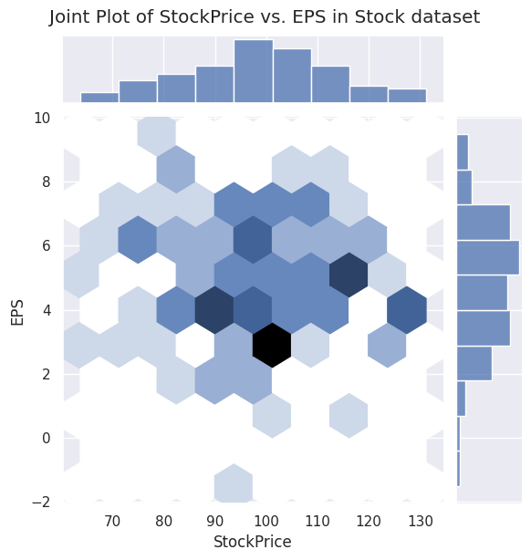

```python
# Create a joint plot
plt.figure(figsize=(8, 6))  # Adjust the figure size for better readability
sns.jointplot(x='StockPrice', y='EPS', data=df, kind='hex')

# Add title (jointplot handles axis labels)
plt.suptitle('Joint Plot of StockPrice vs. EPS in Stock dataset', y=1.02)

# Show the plot
plt.show();
```

### B. Joint plot with scatter

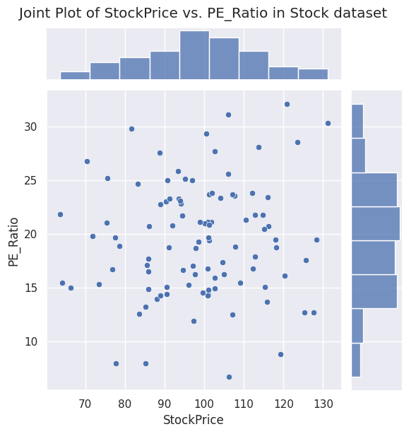

```python
# Create a Jointplot plot
plt.figure(figsize=(8, 6))  # Adjust the figure size for better readability
sns.jointplot(x='StockPrice', y='PE_Ratio', data=df, kind='scatter')

# Add title (jointplot handles axis labels)
plt.suptitle('Joint Plot of StockPrice vs. PE_Ratio in Stock dataset', y=1.02)

# Show the plot
plt.show();
```

### C. Change the hexagon size

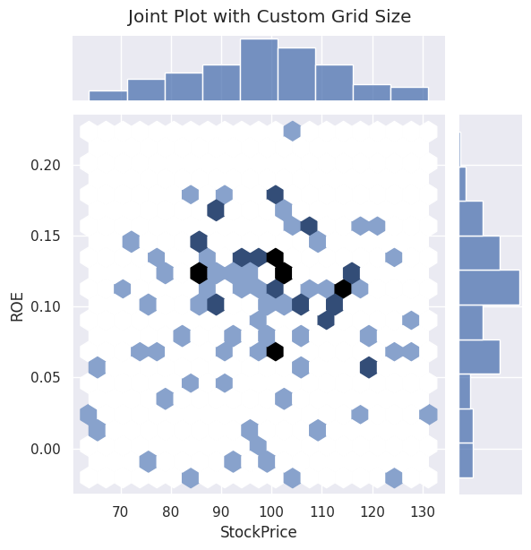

```python
# Change the number of bins (hexagon size)
plt.figure(figsize=(8, 6))
sns.jointplot(x='StockPrice', y='ROE', data=df, kind='hex', gridsize=20) # Try different values for gridsize
plt.suptitle('Joint Plot with Custom Grid Size', y=1.02)
plt.show()
```

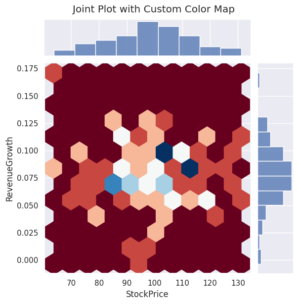

```python
# Change the color map of the hexbins
plt.figure(figsize=(8, 6))
sns.jointplot(x='StockPrice', y='RevenueGrowth', data=df, kind='hex', cmap='RdBu') # Try other colormaps like 'plasma', 'magma', 'cividis'
plt.suptitle('Joint Plot with Custom Color Map', y=1.02)
plt.show();
```

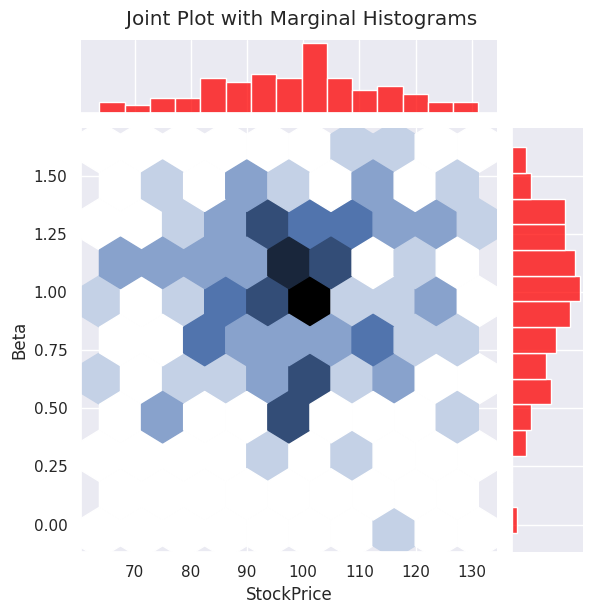

```python
# Add marginal distributions (histograms or KDEs)
plt.figure(figsize=(8, 6))
sns.jointplot(x='StockPrice', y='Beta', data=df, kind='hex', marginal_kws=dict(bins=15, color='red'))
plt.suptitle('Joint Plot with Marginal Histograms', y=1.02)
plt.show();
```

# 4. How to interpret Joint plot

Key Features to Look For:

1. Central Bivariate Plot (Relationship between the two variables):

Pattern/Shape:

- Linear: Points (in a scatter plot or implied by the density in a hexbin or KDE plot) tend to follow a straight line.
  - Positive Linear: As one variable increases, the other tends to increase.
  - Negative Linear: As one variable increases, the other tends to decrease.
- Non-linear: Points follow a curved pattern, indicating a more complex relationship.
- Clustering: Data points form distinct groups or clusters.
- No Clear Pattern: Points are scattered randomly, suggesting a weak or no linear relationship.
- Center (of the relationship):
  - For scatter plots, visually assess the general central tendency of the point cloud.
  - For hexbin plots, the darkest hexagons indicate the areas of highest concentration.
  - For KDE plots, the innermost contours represent the highest density.
  - For regression plots, the regression line shows the central tendency of the linear relationship.
- Spread (of the relationship):
  - A wide scattering of points (or a broad area of density in hexbin/KDE) indicates a weaker relationship or more variability.
  - Points tightly clustered around a line or a dense area suggest a stronger relationship.
- Outliers (in the bivariate space): Points that are far away from the main cluster or pattern in the central plot might be bivariate outliers.
- Gaps (in the bivariate space): Regions in the central plot with very few or no data points might indicate gaps or a lack of observations for those combinations of the two variables.
2. Top Marginal Plot (Distribution of the X-axis Variable):

Shape:

- Symmetric: The distribution is balanced around a central point (e.g., bell-shaped or normal).
- Skewed:
  - Right-skewed (positive skew): The tail of the distribution extends to the right (higher values).
  - Left-skewed (negative skew): The tail of the distribution extends to the left (lower values).
- Unimodal: One peak in the distribution.
- Bimodal or Multimodal: Multiple peaks, suggesting subgroups within the data.
- Center:
  - Look at the peak of the histogram or KDE to estimate the mode (most frequent value).
  - The central tendency can also be inferred visually.
- Spread:
  - A wider histogram or KDE indicates a larger range and more variability in the x-axis variable.
  - A narrower histogram or KDE indicates a smaller range and less variability.
- Outliers: In a histogram, isolated bars far from the main distribution might suggest outliers. The tails of a KDE can also hint at potential outliers.
- Gaps: Empty bins in a histogram indicate gaps in the observed values of the x-axis variable.
3. Right Marginal Plot (Distribution of the Y-axis Variable):

Interpret the shape, center, spread, outliers, and gaps in the distribution of the y-axis variable in the same way as described for the top marginal plot.